# Research Methods in Management

Introduction

### Contents

- Introduction in research methods in management
- Quantitative methods
- Qualitative methods and natural language processing tools
- Data visualization

### Grading

Final Grade = 0.5 X Assignments + 0.5 X Final Project

- **Assignments** - quizes on each seminar based on research articles and real cases
- **Final Project** - data-driven mini-research (individual or in-groups)

### Software

`R programming language`

- Using [RStudio Cloud](https://rstudio.cloud/plans/free) (25 hours/month limit)
- Using [R Desktop installation](https://rstudio-education.github.io/hopr/starting.html)

### Diamond Model

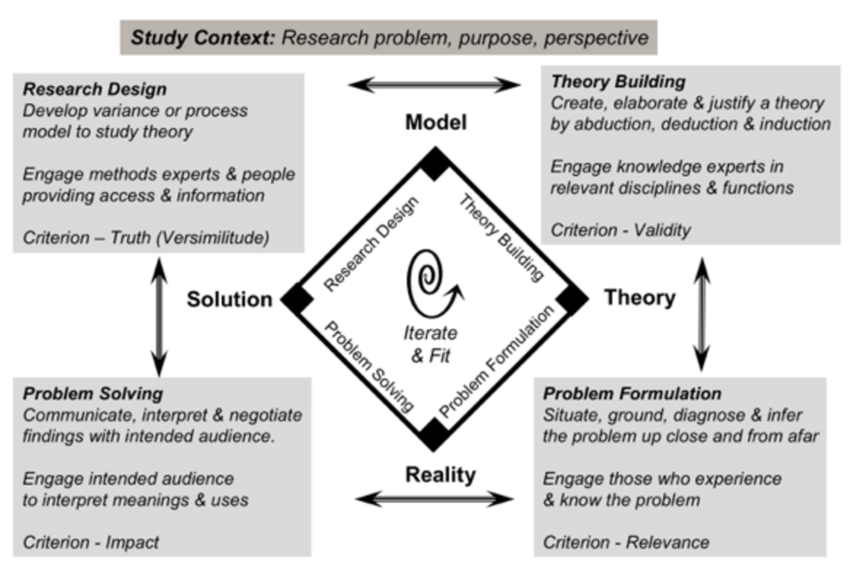

*Source* [Van de Ven, A. 2007. Engaged Scholarship](https://www.ualberta.ca/nursing/media-library/knowledge-utilization-studies-program/knowledge-utilization-colloquia/kt08/vandevenprereadingkt08.pdf)

### Scientific Episode Model

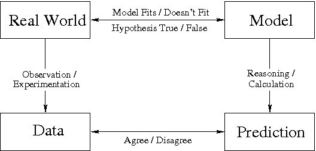

*Source* [Van de Ven, A. 2007. Engaged Scholarship](https://www.ualberta.ca/nursing/media-library/knowledge-utilization-studies-program/knowledge-utilization-colloquia/kt08/vandevenprereadingkt08.pdf)

### Research Structure and Self-Evaluation (1/4)

**Statement of the research problem:**

- is situated in terms of perspective, focus, level, and scope;
- problem symptoms or elements are clearly defined & grounded in reality;
- a diagnosis is made that analyzes patterns or relationships among elements;
- based on the diagnosis, an inference (a claim with reasons) is made for the problem.

**The research question:**

- is stated in analytical and researchable terms;
- permits more than one plausible answer.

### Research Structure and Self-Evaluation (2/4)

**The research proposition (theory):**

- dearly states an expected relationship among concepts or events;
- is supported with an argument (i.e., claim, reasons, evidence, assumptions, & reservations);
- directly addresses the research question and problem;
- is compared with a plausible alternative theory or the status quo answer;
- travels across levels of abstraction.

### Research Structure and Self-Evaluation (3/4)

**The research design clearly spells out:**

- theoretical unit of analysis and unit of observation;
- case/survey/experimental design for variance or process theory;
- sample or replication logic and sample selection;
- definitions and measurement procedures for variables or events;
- threats to internal, statistical, external, & construct validities.

### Research Structure and Self-Evaluation (4/4)

**Research implementation and problem solving for theory and practice:**

- the contributions/implications of the research for science and practice are clearly stated;
- methods for communicating and sharing findings with target audiences/users are discussed;
- statement of how research findings will be used/applied is prudent;
- relevant stakeholders are engaged in each of the above steps.

*Source* [Van de Ven, A. 2007. Engaged Scholarship](https://www.ualberta.ca/nursing/media-library/knowledge-utilization-studies-program/knowledge-utilization-colloquia/kt08/vandevenprereadingkt08.pdf)

### Research Onion

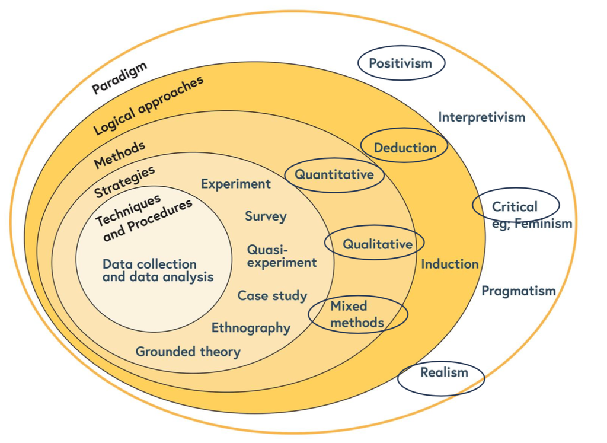

*Source* Hitt, M. A. et al. (2007). Building theoretical and empirical bridges across levels: Multilevel research in management.

### Methodological Fit As a Mean Tendency

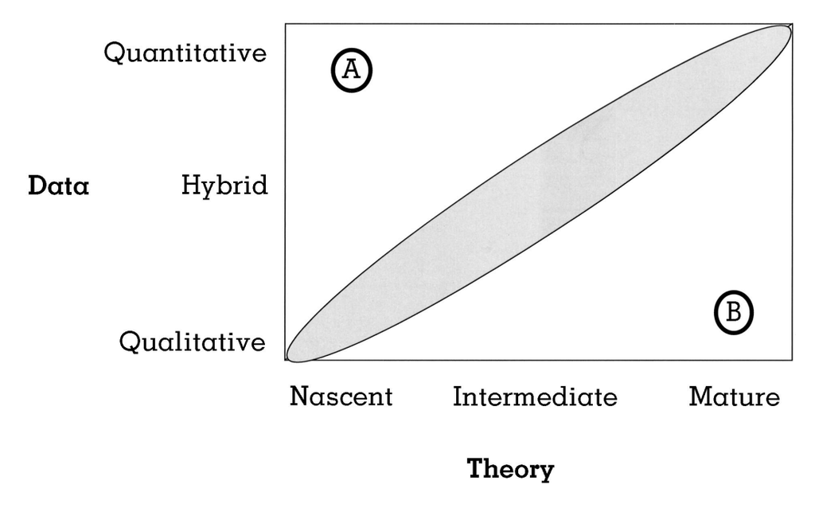

*Source* [Edmondson, A. C., & McManus, S. E. (2007). Methodological fit in management field research](https://www.cebma.org/wp-content/uploads/Edmondson-and-McManus-2007-.pdf)

### Traditional Implicit View of the Field Research Process

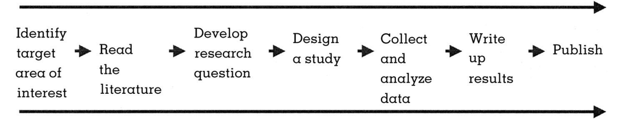

*Source* [Edmondson, A. C., & McManus, S. E. (2007). Methodological fit in management field research](https://www.cebma.org/wp-content/uploads/Edmondson-and-McManus-2007-.pdf)

### Qualitative vs. Quantitative

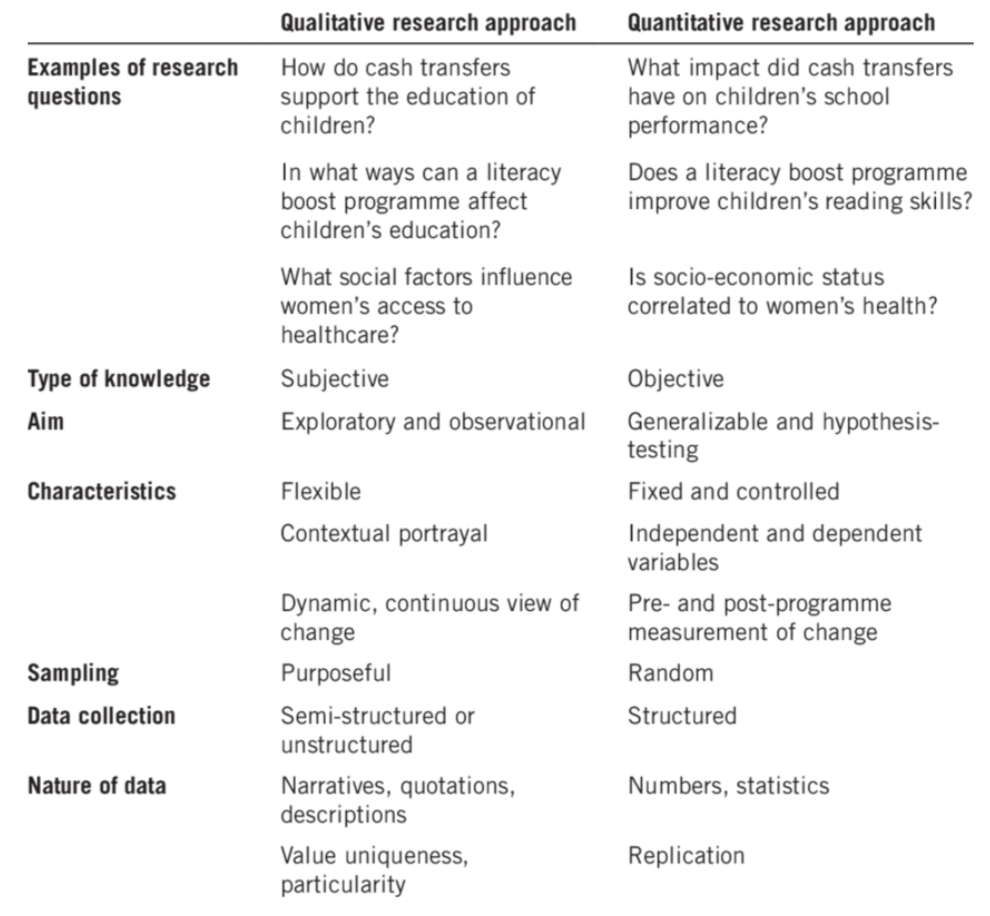

*Source* Skovdal, M., & Cornish, F. (2015). Qualitative research for development: a guide for practitioners.

### For Next Seminar

- Replicate the basic R analysis from [here](http://www.andywills.info/rminr/vbg_explore.html) (Exploring Data)
- Follow and replicate the analysis from [here](https://empirical-methods.com/getting-started-with-dplyr.html) (Lesson 1)
- Read [Paper](https://pubsonline.informs.org/doi/full/10.1287/orsc.2022.1590) (Knowledge Transfer in Companies and Research Methods)
- Read [Paper](https://onlinelibrary.wiley.com/doi/10.1111/1467-8551.12510) (Academics and Management Journals)